# Reproducible Research: Peer Assessment 1

## Assignment Instructions

1.Code for reading in the dataset and/or processing the data 2.Histogram of the total number of steps taken each day 3.Mean and median number of steps taken each day 4.Time series plot of the average number of steps taken 5.The 5-minute interval that, on average, contains the maximum number of steps 6.Code to describe and show a strategy for imputing missing data 7.Histogram of the total number of steps taken each day after missing values are imputed 8.Panel plot comparing the average number of steps taken per 5-minute interval across weekdays and weekends 9.All of the R code needed to reproduce the results (numbers, plots, etc.) in the report

## Loading and preprocessing the data

```r
setwd(getwd())
activity<-read.csv("activity.csv")
```

Exploring the basics of this data

```r
dim(activity)
```

```
## [1] 17568     3
```

```r
names(activity)
```

```
## [1] "steps"    "date"     "interval"
```

```r
head(activity)
```

```
##   steps       date interval
## 1    NA 2012-10-01        0
## 2    NA 2012-10-01        5
## 3    NA 2012-10-01       10
## 4    NA 2012-10-01       15
## 5    NA 2012-10-01       20
## 6    NA 2012-10-01       25
```

```r
str(activity)
```

```
## 'data.frame':    17568 obs. of  3 variables:
##  $ steps   : int  NA NA NA NA NA NA NA NA NA NA ...
##  $ date    : Factor w/ 61 levels "2012-10-01","2012-10-02",..: 1 1 1 1 1 1 1 1 1 1 ...
##  $ interval: int  0 5 10 15 20 25 30 35 40 45 ...
```

```r
#total number of missing data
sum(is.na(activity$steps))/dim(activity)[[1]]
```

```
## [1] 0.1311475
```

```r
#transforming the date column into date format using lubridate
library(lubridate)
activity$date<-ymd(activity$date)
length(unique(activity$date))
```

```
## [1] 61
```

## Step 2

## Histogram of the total number of steps taken each day

```r
library(ggplot2)
D2<-data.frame(tapply(activity$steps,activity$date,sum,na.rm=TRUE))
D2$date<-rownames(D2)
rownames(D2)<-NULL
names(D2)[[1]]<-"Total Steps"
png("plot1.png")
#Total Steps by date bar chart
ggplot(D2,aes(y=D2$`Total Steps`,x=D2$date))+geom_bar(stat="identity") + ylab("Total Steps")+xlab("Date")+ggtitle("Total Steps by date")
dev.off()
```

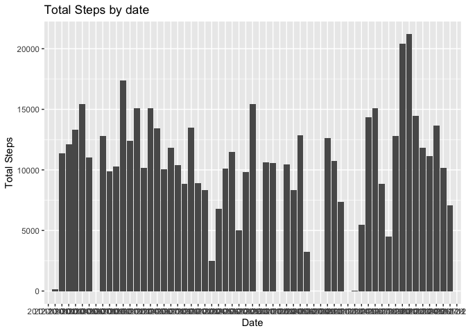

```r
ggplot(D2,aes(y=D2$`Total Steps`,x=D2$date))+geom_bar(stat="identity") + ylab("Total Steps")+xlab("Date")+ggtitle("Total Steps by date")
```

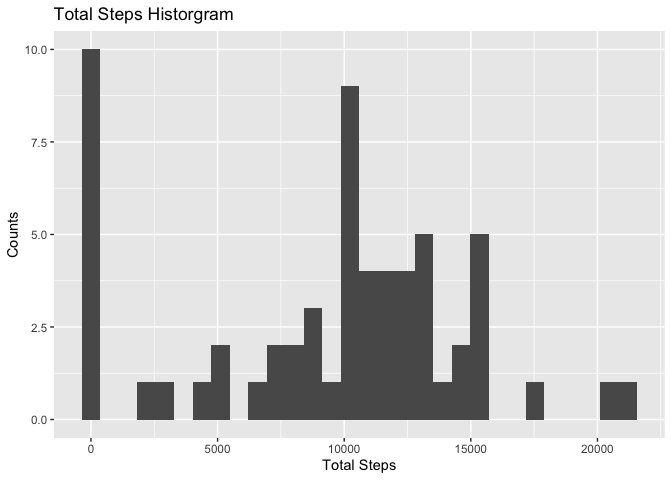

```r
#Histogram of total steps
qplot(D2$`Total Steps`,geom="histogram",xlab="Total Steps",ylab="Counts",main="Total Steps Historgram")
```

```r
png("plot1.1.png")
qplot(D2$`Total Steps`,geom="histogram",xlab="Total Steps",ylab="Counts",main="Total Steps Historgram")
dev.off()
```

## Step 3

```r
library(dplyr)
D3<-data.frame(round(tapply(activity$steps,activity$date,mean,na.rm=TRUE),2))
D3$date<-rownames(D3)
rownames(D3)<-NULL
names(D3)[[1]]<-"Mean Steps"
temp<-activity%>%select(date,steps) %>% group_by(date) %>% summarise(median(steps))
names(temp)[[2]]<-"Median Steps"
D3$median<-temp$`Median Steps`
D3<-D3 %>% select(date,`Mean Steps`,median)
```

## Step 4

## Time series plot of the average number of steps taken

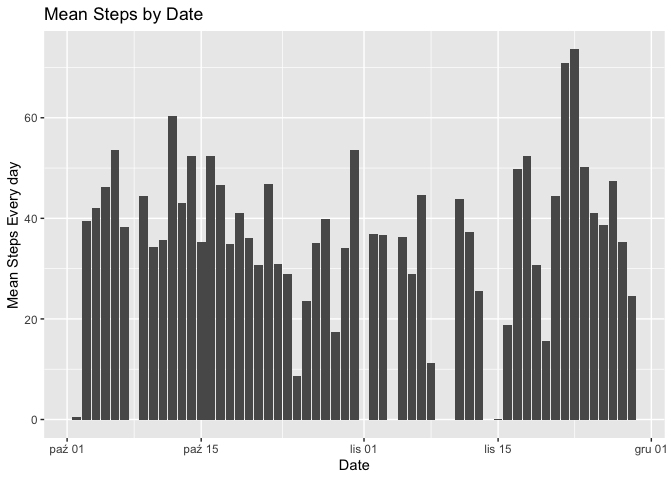

```r
D4<-D3
D4$date<-as.Date(D4$date,format="%Y-%m-%d")
ggplot(D4,aes(x=D4$date,y=D4$`Mean Steps`))+geom_bar(stat="identity")+scale_x_date()+ylab("Mean Steps Every day")+xlab("Date")+ggtitle("Mean Steps by Date")
```

```r
png("plot4.png")
ggplot(D4,aes(x=D4$date,y=D4$`Mean Steps`))+geom_bar(stat="identity")+scale_x_date()+ylab("Mean Steps Every day")+xlab("Date")+ggtitle("Mean Steps by Date")
dev.off()
```

## Step 5

```r
#This is assuming that the words on average means averaging steps by date and interval
activity$interval<-factor(activity$interval)
D5<-aggregate(data=activity,steps~date+interval,FUN="mean")
D5<-aggregate(data=D5,steps~interval,FUN="max")
```

## Step 6

## Code to describe and show a strategy for imputing missing data

## Here we are using the values to substitute out the missing values in the original data set.

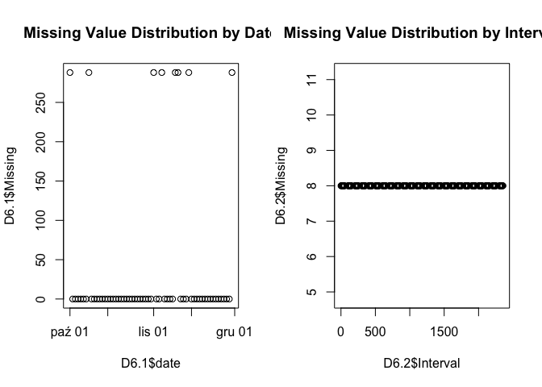

```r
D6<-activity
D6$Missing<-is.na(D6$steps)
D6<-aggregate(data=D6,Missing~date+interval,FUN="sum")
D6.1<-data.frame(tapply(D6$Missing,D6$date,sum))
D6.1$date<-rownames(D6.1)
rownames(D6.1)<-NULL
names(D6.1)<-c("Missing","date")
D6.1$date<-as.Date(D6.1$date,format="%Y-%m-%d")
D6.2<-data.frame(tapply(D6$Missing,D6$interval,sum))
D6.2$date<-rownames(D6.2)
rownames(D6.2)<-NULL
names(D6.2)<-c("Missing","Interval")
par(mfrow=c(1,2))
plot(y=D6.1$Missing,x=D6.1$date,main="Missing Value Distribution by Date")
plot(y=D6.2$Missing,x=D6.2$Interval,main="Missing Value Distribution by Interval")
```

```r
table(activity$date)
```

```
##
## 2012-10-01 2012-10-02 2012-10-03 2012-10-04 2012-10-05 2012-10-06 2012-10-07
##        288        288        288        288        288        288        288
## 2012-10-08 2012-10-09 2012-10-10 2012-10-11 2012-10-12 2012-10-13 2012-10-14
##        288        288        288        288        288        288        288
## 2012-10-15 2012-10-16 2012-10-17 2012-10-18 2012-10-19 2012-10-20 2012-10-21
##        288        288        288        288        288        288        288
## 2012-10-22 2012-10-23 2012-10-24 2012-10-25 2012-10-26 2012-10-27 2012-10-28
##        288        288        288        288        288        288        288
## 2012-10-29 2012-10-30 2012-10-31 2012-11-01 2012-11-02 2012-11-03 2012-11-04
##        288        288        288        288        288        288        288
## 2012-11-05 2012-11-06 2012-11-07 2012-11-08 2012-11-09 2012-11-10 2012-11-11
##        288        288        288        288        288        288        288
## 2012-11-12 2012-11-13 2012-11-14 2012-11-15 2012-11-16 2012-11-17 2012-11-18
##        288        288        288        288        288        288        288
## 2012-11-19 2012-11-20 2012-11-21 2012-11-22 2012-11-23 2012-11-24 2012-11-25
##        288        288        288        288        288        288        288
## 2012-11-26 2012-11-27 2012-11-28 2012-11-29 2012-11-30
##        288        288        288        288        288
```

```r
#Dates that have missing values
library(lubridate)
D6.3<-as.data.frame(D6.1) %>% select(date,Missing) %>% arrange(desc(Missing))
D6.3<-D6.3[which(D6.3$Missing!=0),]
D6.3$Weekday<-wday(D6.3$date,label=TRUE)
D6.4<-activity
D6.4$weekday<-wday(D6.4$date,label=TRUE)
#Finding the mean of steps every monday, and every interval
D6.5<-aggregate(data=D6.4,steps~interval+weekday,FUN="mean",na.rm=TRUE)
#Merge the pre-imputation table D6.4 table with the average table D6.5
D6.6<-merge(x=D6.4,y=D6.5,by.x=c("interval","weekday"),by.y=c("interval","weekday"),all.x=TRUE)
#Conditionally replacing the steps.x column NA value with the values from steps.y column value
D6.6$Steps.Updated<-0
for (i in 1:dim(D6.6)[[1]]){
if(is.na(D6.6[i,3])){D6.6[i,6]=D6.6[i,5]}
else {D6.6[i,6]=D6.6[i,3]}
}
#Now simplify the imputed analytical data frame
D6.6 <-D6.6  %>% select(date,weekday,interval,Steps.Updated)
names(D6.6)[[4]]<-"Steps"
```

## Step 7

```r
png("plot7.png")
qplot(D6.6$Steps,geom="histogram",main="Histogram of total steps taken, after imputation",xlab="Steps",ylab="Count")
dev.off()
```

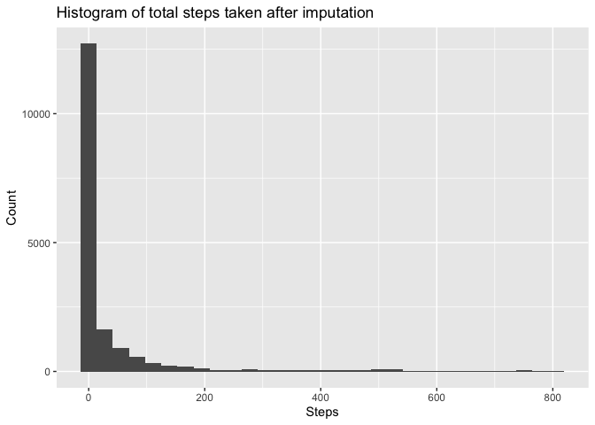

```r
qplot(D6.6$Steps,geom="histogram",main="Histogram of total steps taken after imputation",xlab="Steps",ylab="Count")
```

## Step 8

```r
D8<-D6.6
levels(D8$weekday)<-c(1,2,3,4,5,6,7)
D8$WDWE<-D8$weekday %in% c(1,2,3,4,5)
D8.1<-aggregate(data=D8,Steps~interval+WDWE,mean,na.rm=TRUE)
D8.1$WDWE<-as.factor(D8.1$WDWE)
levels(D8.1$WDWE)<-c("Weekend","Weekday")
png("plot8.png")
ggplot(data=D8.1,aes(y=Steps,x=interval,group=1,color=WDWE))+geom_line() +scale_x_discrete(breaks = seq(0, 2500, by = 300))+ylab("Mean Steps")+xlab("Intervals")+ggtitle("Mean steps across intervals by Weekend and Weekday")
dev.off()
```

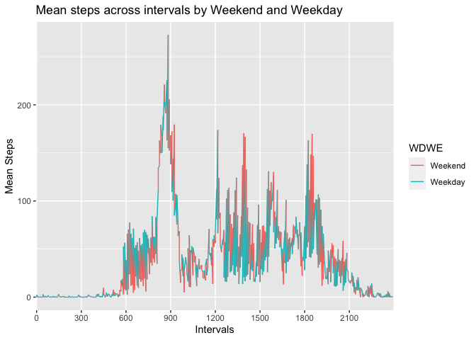

```r
ggplot(data=D8.1,aes(y=Steps,x=interval,group=1,color=WDWE))+geom_line() +scale_x_discrete(breaks = seq(0, 2500, by = 300))+ylab("Mean Steps")+xlab("Intervals")+ggtitle("Mean steps across intervals by Weekend and Weekday")
```

```
## (loaded the KernSmooth namespace)
```

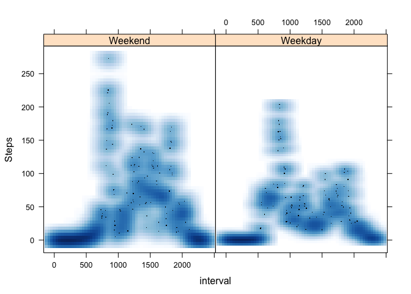

```r
#Producing the panel plot
D8.1$interval<-as.numeric(as.character(D8.1$interval))
library(lattice)
xyplot(data=D8.1,Steps~interval|WDWE, grid = TRUE, type = c("p", "smooth"), lwd = 4,panel = panel.smoothScatter)
```

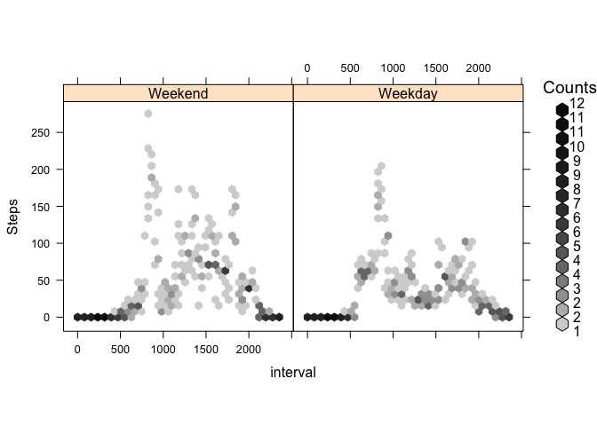

```r
library(hexbin)
hexbinplot(data=D8.1,Steps~interval|WDWE, aspect = 1, bins=50)
```

```r
png("plot8.1.png")
xyplot(data=D8.1,Steps~interval|WDWE, grid = TRUE, type = c("p", "smooth"), lwd = 4,panel = panel.smoothScatter)
dev.off()
```

```r
png("plot8.2.png")
hexbinplot(data=D8.1,Steps~interval|WDWE, aspect = 1, bins=50)
dev.off()
```